# Gaming vs. Academic Performance

INFO 432 — Group 5 Final Report

Jeffrey Cheung, Drew Jones, Danny Eapen, Joel Thomas

August 11, 2026

# 1 Introduction

## 1.1 Research questions

Video games are the default leisure activity for a large share of college students, and the folk claim that gaming “ruins your grades” is repeated far more often than it is measured. This report takes a dataset of 8,000 students and asks three questions:

1. **Which lifestyle factors actually relate to grades?** Gaming hours, study hours, sleep hours, class attendance, and a self-reported gaming addiction score are the five candidates. We test each one for a statistically significant relationship with grades.
2. **Where are the thresholds?** A significant correlation says a relationship exists but not where it starts to matter. We look for the specific values — hours of gaming per day, hours of study — at which average performance visibly steps down.
3. **How well can grades be predicted?** We build and compare regression models, and score them on students the model never saw, so the reported accuracy is honest.

## 1.2 The dataset

The data comes from the Kaggle dataset [Gaming vs Academic Performance](https://www.kaggle.com/datasets/nalisha/gaming-vs-academic-performance): 8,000 student records with 14 columns covering demographics, gaming habits, study habits, sleep, attendance, stress, and a final grade.

```r
df_raw <- read_csv("data/Gaming_Academic_Performance.csv", show_col_types = FALSE)

tibble(
  Column = names(df_raw),
  Type   = map_chr(df_raw, ~ class(.x)[1]),
  Example = map_chr(df_raw, ~ as.character(.x[1]))
) %>%
  tbl(caption = "Raw dataset structure (8,000 rows x 14 columns)")
```

Raw dataset structure (8,000 rows x 14 columns)

| Column | Type | Example |
| --- | --- | --- |
| student_id | numeric | 1 |
| age | numeric | 22 |
| gender | character | Male |
| gaming_hours | numeric | 7.23 |
| study_hours | numeric | 8.78 |
| sleep_hours | numeric | 6.96 |
| attendance | numeric | 91.44 |
| gaming_genre | character | FPS |
| social_activity | numeric | 3.25 |
| device_usage | numeric | 9.36 |
| reaction_time_ms | numeric | 235.84 |
| addiction_score | numeric | 14.69 |
| stress_level | character | Low |
| grades | numeric | 86.4595546633377 |

A caveat we state up front and return to in the limitations: this dataset is almost certainly **simulated rather than collected**. The relationships in it are far cleaner than real survey data ever is. Everything below is a correct application of the method to the data as given; none of it is a real-world claim about students.

# 2 Data cleaning

*Source script: `scripts/cleaning.R`*

## 2.1 Missing values

```r
missing <- colSums(is.na(df_raw))

tibble(Column = names(missing), `Missing values` = as.integer(missing)) %>%
  tbl(caption = "Missing value count by column")
```

Missing value count by column

| Column | Missing values |
| --- | --- |
| student_id | 0 |
| age | 0 |
| gender | 0 |
| gaming_hours | 0 |
| study_hours | 0 |
| sleep_hours | 0 |
| attendance | 0 |
| gaming_genre | 0 |
| social_activity | 0 |
| device_usage | 0 |
| reaction_time_ms | 0 |
| addiction_score | 0 |
| stress_level | 0 |
| grades | 0 |

## 2.2 The grades problem

The grade column runs past 100, which is not possible on a normal percentage scale.

```r
over_100 <- df_raw %>% filter(grades > 100)

tibble(
  Statistic = c("Minimum", "Median", "Mean", "Maximum",
                "Records over 100", "Percent of sample"),
  Value = c(
    round(min(df_raw$grades), 2),
    round(median(df_raw$grades), 2),
    round(mean(df_raw$grades), 2),
    round(max(df_raw$grades), 2),
    nrow(over_100),
    round(100 * nrow(over_100) / nrow(df_raw), 2)
  )
) %>%
  tbl(caption = "Grade distribution before cleaning")
```

Grade distribution before cleaning

| Statistic | Value |
| --- | --- |
| Minimum | 0.00 |
| Median | 67.07 |
| Mean | 66.18 |
| Maximum | 118.63 |
| Records over 100 | 134.00 |
| Percent of sample | 1.68 |

Before deciding what to do with these 134 records, we checked whether they look like data entry errors or like genuine high performers:

```r
bind_rows(
  over_100 %>%
    summarise(across(c(gaming_hours, study_hours, sleep_hours, attendance,
                       addiction_score), mean)) %>%
    mutate(Group = "Grades over 100", .before = 1),
  df_raw %>%
    filter(grades <= 100) %>%
    summarise(across(c(gaming_hours, study_hours, sleep_hours, attendance,
                       addiction_score), mean)) %>%
    mutate(Group = "Everyone else", .before = 1)
) %>%
  tbl(caption = "Profile of the over-100 records vs. the rest of the sample", digits = 2)
```

Profile of the over-100 records vs. the rest of the sample

| Group | gaming_hours | study_hours | sleep_hours | attendance | addiction_score |
| --- | --- | --- | --- | --- | --- |
| Grades over 100 | 2.66 | 8.65 | 7.37 | 84.32 | 7.20 |
| Everyone else | 4.11 | 5.41 | 6.48 | 79.81 | 9.95 |

They study more, game less, attend more, and score lower on addiction — exactly the profile of the strongest students. So these are informative cases, not noise. **We capped them at 100 rather than dropping them**, which keeps their predictor values in the sample at the cost of censoring their outcome. That censoring is carried forward as a known limitation in the modeling section.

```r
df <- df_raw %>%
  mutate(grades = pmin(grades, 100)) %>%
  mutate(
    gender        = as.factor(gender),
    gaming_genre  = as.factor(gaming_genre),
    stress_level  = factor(stress_level, levels = c("Low", "Medium", "High"),
                           ordered = TRUE)
  )

write_csv(df, "data/cleaned_data.csv")
```

## 2.3 Post-cleaning distribution

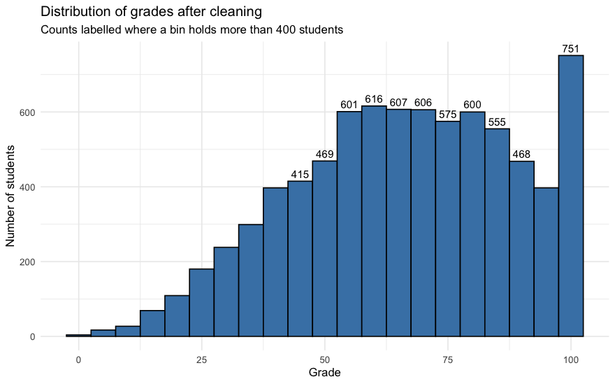

```r
p_hist <- ggplot(df, aes(x = grades)) +
  geom_histogram(binwidth = 5, color = "black", fill = "steelblue") +
  stat_bin(binwidth = 5, geom = "text",
           aes(label = ifelse(after_stat(count) > 400, after_stat(count), "")),
           vjust = -0.5, size = 3.5) +
  labs(title = "Distribution of grades after cleaning",
       subtitle = "Counts labelled where a bin holds more than 400 students",
       x = "Grade", y = "Number of students") +
  theme_minimal()

ggsave("output/grade_distribution_graph.png", p_hist, width = 8, height = 5, dpi = 110)
p_hist
```

# 3 Exploratory data analysis

*Source script: `scripts/eda.R`*

## 3.1 Correlation matrix

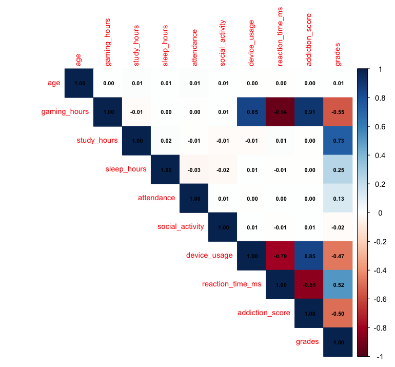

```r
numeric_vars <- df %>% select(where(is.numeric)) %>% select(-student_id)
corr_matrix  <- cor(numeric_vars, use = "complete.obs")

png("output/correlation_matrix.png", width = 1400, height = 1300, res = 170)
corrplot(corr_matrix, method = "color", type = "upper", tl.cex = 0.7,
         addCoef.col = "black", number.cex = 0.55)
invisible(dev.off())

corrplot(corr_matrix, method = "color", type = "upper", tl.cex = 0.8,
         addCoef.col = "black", number.cex = 0.6)
```

Two things stand out immediately and shape the rest of the analysis:

```r
tibble(
  Pair = c("study_hours ~ grades", "gaming_hours ~ grades",
           "addiction_score ~ grades", "attendance ~ grades",
           "sleep_hours ~ grades", "addiction_score ~ gaming_hours"),
  Correlation = c(
    cor(df$study_hours, df$grades), cor(df$gaming_hours, df$grades),
    cor(df$addiction_score, df$grades), cor(df$attendance, df$grades),
    cor(df$sleep_hours, df$grades), cor(df$addiction_score, df$gaming_hours)
  )
) %>%
  tbl(caption = "Correlations worth naming")
```

Correlations worth naming

| Pair | Correlation |
| --- | --- |
| study_hours ~ grades | 0.733 |
| gaming_hours ~ grades | -0.552 |
| addiction_score ~ grades | -0.496 |
| attendance ~ grades | 0.130 |
| sleep_hours ~ grades | 0.249 |
| addiction_score ~ gaming_hours | 0.909 |

First, study hours and gaming hours are the two dominant relationships and they point in opposite directions. Second, **addiction score correlates 0.91 with gaming hours** — those two columns are close to the same measurement, which becomes the central issue in the regression section.

## 3.2 Grades vs. each factor

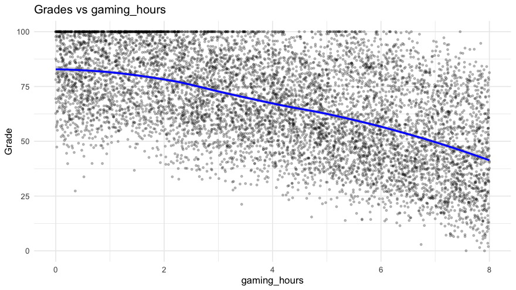

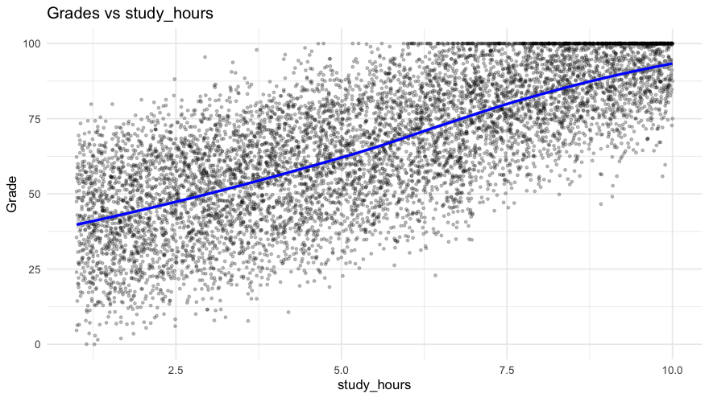

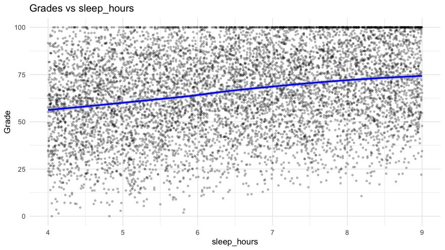

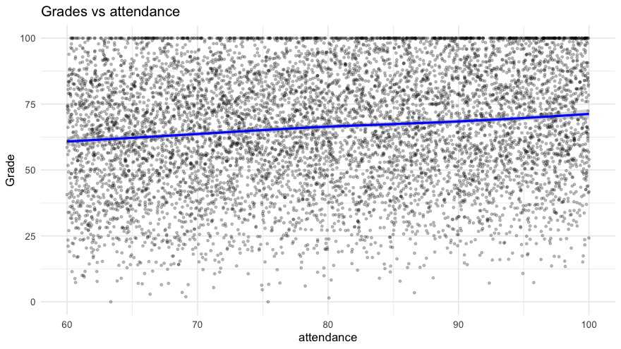

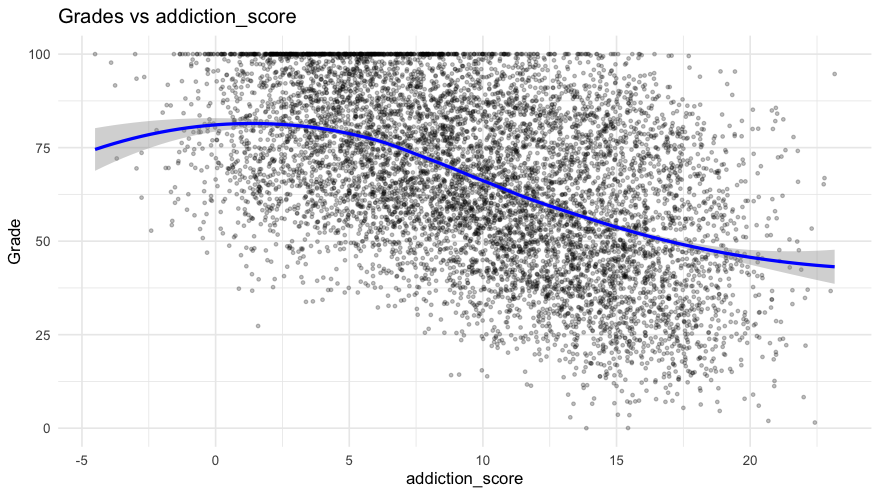

```r
plot_vars <- c("gaming_hours", "study_hours", "sleep_hours", "attendance",
               "addiction_score")

for (v in plot_vars) {
  p <- ggplot(df, aes(x = .data[[v]], y = grades)) +
    geom_point(alpha = 0.25, size = 0.8) +
    geom_smooth(method = "loess", color = "blue", se = TRUE) +
    labs(title = paste("Grades vs", v), x = v, y = "Grade") +
    theme_minimal()

  # Explicit size, otherwise ggsave inherits the device dimensions and writes
  # multi-megabyte files.
  ggsave(paste0("output/scatter_", v, ".png"), plot = p,
         width = 8, height = 5, dpi = 100)
  print(p)
}
```

The gaming and addiction curves **bend** rather than run straight — the penalty per extra hour is not constant. That is the motivation for the squared terms in the modeling section.

## 3.3 Grades by categorical variables

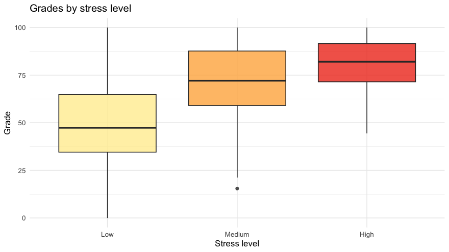

```r
ggplot(df, aes(x = stress_level, y = grades, fill = stress_level)) +
  geom_boxplot(alpha = 0.8) +
  scale_fill_brewer(palette = "YlOrRd") +
  labs(title = "Grades by stress level", x = "Stress level", y = "Grade") +
  theme_minimal() +
  theme(legend.position = "none")
```

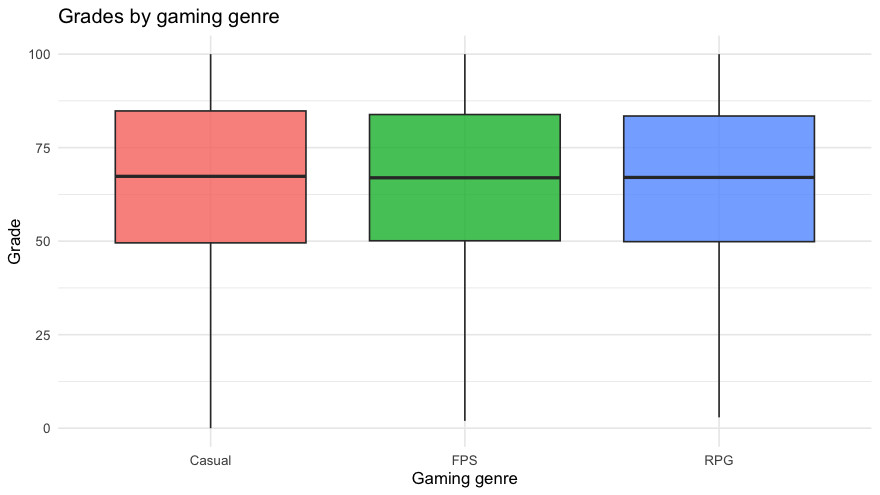

```r
ggplot(df, aes(x = gaming_genre, y = grades, fill = gaming_genre)) +
  geom_boxplot(alpha = 0.8) +
  labs(title = "Grades by gaming genre", x = "Gaming genre", y = "Grade") +
  theme_minimal() +
  theme(legend.position = "none")
```

# 4 Statistical testing

*Source script: `scripts/stat_testing.R`*

**Setup.** We use $\alpha = 0.05$. For each factor the null hypothesis is that it has no relationship with grades; the alternative is that it does.

```r
vars <- c("gaming_hours", "study_hours", "sleep_hours", "attendance",
          "addiction_score")
```

## 4.1 A note on method: why we dropped ANOVA

Our first version of this analysis used one-way ANOVA with `factor(gaming_hours)`, `factor(attendance)`, and so on. That was the wrong tool, and it gave us wrong answers. ANOVA compares a handful of groups, but these factors are continuous measurements, so `factor()` creates one group per distinct value:

```r
cell_sizes <- tibble(
  variable     = vars,
  n_levels     = map_int(vars, ~ length(unique(df[[.x]]))),
  obs_per_cell = round(map_dbl(vars, ~ nrow(df) / length(unique(df[[.x]]))), 2)
)

tbl(cell_sizes, caption = "Distinct values per factor — why the ANOVA breaks down",
    digits = 2)
```

Distinct values per factor — why the ANOVA breaks down

| variable | n_levels | obs_per_cell |
| --- | --- | --- |
| gaming_hours | 801 | 9.99 |
| study_hours | 901 | 8.88 |
| sleep_hours | 501 | 15.97 |
| attendance | 3472 | 2.30 |
| addiction_score | 2039 | 3.92 |

Attendance has 3,472 distinct values across 8,000 students — roughly **two students per group**. With cells that small there is almost nothing left to average within a group, which is exactly what the F test needs, and the test reported attendance as *not* significant when it actually is. The correlation tests and the regression below are the results we use; the ANOVA is kept in section 4.4 purely to document the comparison.

## 4.2 Test 1 — correlation of each factor with grades

This is the direct replacement for the one-way ANOVA. It asks the same question, “does this factor relate to grades”, but it uses the fact that the values are *ordered* instead of throwing that information away.

```r
cor_results <- map_dfr(vars, function(v) {
  ct <- cor.test(df[[v]], df$grades)
  m  <- lm(df$grades ~ df[[v]])
  tibble(
    variable   = v,
    r          = round(unname(ct$estimate), 3),
    p_value    = ct$p.value,
    slope      = round(unname(coef(m)[2]), 3),
    r_squared  = round(summary(m)$r.squared, 4),
    conclusion = ifelse(ct$p.value < 0.05, "Reject H0", "Fail to reject")
  )
})

write_csv(cor_results, "output/correlation_results.csv")

cor_results %>%
  mutate(p_value = format.pval(p_value, digits = 3, eps = 1e-300)) %>%
  tbl(caption = "Each factor tested against grades on its own")
```

Each factor tested against grades on its own

| variable | r | p_value | slope | r_squared | conclusion |
| --- | --- | --- | --- | --- | --- |
| gaming_hours | -0.552 | < 1e-300 | -5.323 | 0.305 | Reject H0 |
| study_hours | 0.733 | < 1e-300 | 6.332 | 0.537 | Reject H0 |
| sleep_hours | 0.249 | 1.10e-113 | 3.847 | 0.062 | Reject H0 |
| attendance | 0.130 | 1.52e-31 | 0.250 | 0.017 | Reject H0 |
| addiction_score | -0.496 | < 1e-300 | -2.192 | 0.246 | Reject H0 |

**Every factor, including attendance, is significant on its own.** The `slope` column is the part worth quoting in a summary: it converts a p-value into plain language — one extra hour of study is worth about 6.3 grade points, one extra hour of gaming about -5.3.

## 4.3 Test 2 — all five factors in one regression

The correlations above look at one factor at a time, so a factor can look important just by riding along with another one. Putting them in the same model shows what each factor is worth *once the others are already accounted for*.

```r
full_model <- lm(
  grades ~ gaming_hours + study_hours + sleep_hours + attendance + addiction_score,
  data = df
)

reg_results <- tidy(full_model) %>%
  mutate(conclusion = ifelse(p.value < 0.05, "Reject H0", "Fail to reject"))

write_csv(reg_results, "output/regression_results.csv")

reg_results %>%
  mutate(p.value = format.pval(p.value, digits = 3, eps = 1e-300)) %>%
  tbl(caption = sprintf("Multiple regression, all five factors (adjusted R-squared = %.4f)",
                        summary(full_model)$adj.r.squared),
      digits = 4)
```

Multiple regression, all five factors (adjusted R-squared = 0.9106)

| term | estimate | std.error | statistic | p.value | conclusion |
| --- | --- | --- | --- | --- | --- |
| (Intercept) | 7.0877 | 0.6616 | 10.7135 | 1.33e-26 | Reject H0 |
| gaming_hours | -5.3381 | 0.0773 | -69.0288 | < 1e-300 | Reject H0 |
| study_hours | 6.2532 | 0.0289 | 216.4639 | < 1e-300 | Reject H0 |
| sleep_hours | 3.7294 | 0.0516 | 72.2867 | < 1e-300 | Reject H0 |
| attendance | 0.2757 | 0.0064 | 42.9098 | < 1e-300 | Reject H0 |
| addiction_score | 0.0416 | 0.0355 | 1.1737 | 0.241 | Fail to reject |

**Addiction score is the one factor that stops being significant here**, and the reason is the 0.91 correlation with gaming hours we flagged in the EDA. It is not adding a separate effect; it is measuring gaming a second time. We report gaming hours as the real driver.

## 4.4 ANOVA vs. correlation, side by side

```r
# The slow block: aov() is fitting thousands of levels per model.
anova_list <- list(
  gaming     = aov(df$grades ~ factor(df$gaming_hours)),
  study      = aov(df$grades ~ factor(df$study_hours)),
  sleep      = aov(df$grades ~ factor(df$sleep_hours)),
  attendance = aov(df$grades ~ factor(df$attendance)),
  addiction  = aov(df$grades ~ factor(df$addiction_score))
)

anova_tables <- map_dfr(names(anova_list), function(n) {
  tab <- as.data.frame(summary(anova_list[[n]])[[1]])
  tab$term  <- rownames(tab)
  tab$model <- n
  tab
})
write_csv(anova_tables, "output/anova_results.csv")

comparison <- tibble(
  variable     = vars,
  obs_per_cell = cell_sizes$obs_per_cell,
  anova_p      = map_dbl(anova_list, ~ summary(.x)[[1]][["Pr(>F)"]][1]),
  correct_p    = cor_results$p_value
) %>%
  mutate(
    anova_says   = ifelse(anova_p   < 0.05, "Reject H0", "Fail to reject"),
    correct_says = ifelse(correct_p < 0.05, "Reject H0", "Fail to reject"),
    agrees       = ifelse(anova_says == correct_says, "", "DISAGREES")
  )

write_csv(comparison, "output/method_comparison.csv")

comparison %>%
  mutate(across(c(anova_p, correct_p), ~ format.pval(.x, digits = 3, eps = 1e-300))) %>%
  tbl(caption = "Where the wrong test changed the answer", digits = 2)
```

Where the wrong test changed the answer

| variable | obs_per_cell | anova_p | correct_p | anova_says | correct_says | agrees |
| --- | --- | --- | --- | --- | --- | --- |
| gaming_hours | 9.99 | < 1e-300 | < 1e-300 | Reject H0 | Reject H0 |  |
| study_hours | 8.88 | < 1e-300 | < 1e-300 | Reject H0 | Reject H0 |  |
| sleep_hours | 15.97 | 5.65e-36 | 1.10e-113 | Reject H0 | Reject H0 |  |
| attendance | 2.30 | 0.114 | 1.52e-31 | Fail to reject | Reject H0 | DISAGREES |
| addiction_score | 3.92 | 5.26e-129 | < 1e-300 | Reject H0 | Reject H0 |  |

## 4.5 Section conclusion

- **Study hours, gaming hours, sleep hours, and attendance** are statistically significant predictors of grades, both individually and when tested together.
- **Addiction score** is significant on its own but not once the other factors are included. It is a proxy for gaming hours, not a separate effect.
- **Attendance is significant** — the opposite of what our original ANOVA concluded, and the reason we changed method.

# 5 Threshold analysis

*Source script: `scripts/threshold_analysis.R`*

Objective 2 is to find the values *within* each factor where performance shifts. We use two independent approaches so the cutoffs can be cross-checked: a decision tree, which picks its own split points, and binned averages, which show where the mean grade steps down.

## 5.1 Letter grades

Converting to a standard letter scale lets a threshold be stated in language a reader actually feels — “drops from A- to B+” rather than “drops 2.8 points”.

```r
grade_breaks <- c(-Inf, 60, 63, 67, 70, 73, 77, 80, 83, 87, 90, 93, Inf)
grade_labels <- c("F", "D-", "D", "D+", "C-", "C", "C+", "B-", "B", "B+", "A-", "A")

to_letter <- function(x) cut(x, breaks = grade_breaks, labels = grade_labels,
                             right = FALSE)

df <- df %>% mutate(letter_grade = to_letter(grades))
write_csv(df, "data/cleaned_data_with_grades.csv")

df %>%
  count(letter_grade) %>%
  mutate(pct = round(100 * n / sum(n), 1)) %>%
  tbl(caption = "Letter grade distribution", digits = 1)
```

Letter grade distribution

| letter_grade | n | pct |
| --- | --- | --- |
| F | 3131 | 39.1 |
| D- | 369 | 4.6 |
| D | 489 | 6.1 |
| D+ | 362 | 4.5 |
| C- | 348 | 4.3 |
| C | 468 | 5.8 |
| C+ | 382 | 4.8 |
| B- | 335 | 4.2 |
| B | 446 | 5.6 |
| B+ | 295 | 3.7 |
| A- | 268 | 3.4 |
| A | 1107 | 13.8 |

## 5.2 Approach 1 — decision tree

`reaction_time_ms` is deliberately excluded. It is a *consequence* of gaming, not a cause of grades, so letting it split would steal credit from `gaming_hours` and make the cutoffs harder to interpret.

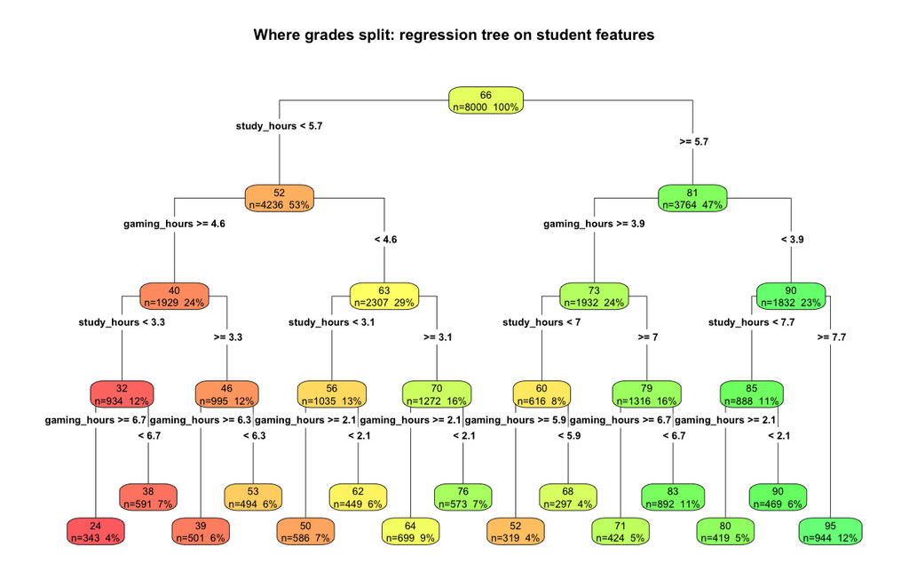

```r
predictors <- c("gaming_hours", "study_hours", "sleep_hours", "attendance",
                "addiction_score", "device_usage", "social_activity", "age",
                "stress_level", "gaming_genre")

tree_data <- df %>%
  select(grades, all_of(predictors)) %>%
  mutate(across(where(is.character), as.factor))

set.seed(432)
tree <- rpart(grades ~ ., data = tree_data, method = "anova",
              control = rpart.control(cp = 0.005, maxdepth = 4, minbucket = 100))

png("output/decision_tree.png", width = 1600, height = 1000, res = 150)
rpart.plot(tree, type = 4, extra = 101, box.palette = "RdYlGn",
           main = "Where grades split: regression tree on student features")
invisible(dev.off())

rpart.plot(tree, type = 4, extra = 101, box.palette = "RdYlGn",
           main = "Where grades split: regression tree on student features")
```

```r
# rpart stores splits per node in the order: primary, competitors, surrogates.
# Walk the frame to pick out only the primary split of each internal node.
frame    <- tree$frame
splits   <- as.data.frame(tree$splits)
internal <- which(frame$var != "<leaf>")

split_rows <- integer(0)
idx <- 1
for (i in internal) {
  split_rows <- c(split_rows, idx)
  idx <- idx + 1 + frame$ncompete[i] + frame$nsurrogate[i]
}

node_ids <- as.numeric(rownames(frame))[internal]

tree_splits <- tibble(
  depth       = floor(log2(node_ids)) + 1,
  # rpart makes rownames unique by appending .1, .2 ... strip that back off
  variable    = sub("\\.[0-9]+$", "", rownames(splits)[split_rows]),
  split_value = round(splits$index[split_rows], 2),
  n_at_node   = frame$n[internal],
  mean_grade  = round(frame$yval[internal], 1)
) %>% arrange(depth, desc(n_at_node))

write_csv(tree_splits, "output/tree_splits.csv")
tbl(tree_splits, caption = "Tree split points — the candidate cutoffs", digits = 2)
```

Tree split points — the candidate cutoffs

| depth | variable | split_value | n_at_node | mean_grade |
| --- | --- | --- | --- | --- |
| 1 | study_hours | 5.70 | 8000 | 66.1 |
| 2 | gaming_hours | 4.61 | 4236 | 52.4 |
| 2 | gaming_hours | 3.95 | 3764 | 81.4 |
| 3 | study_hours | 3.08 | 2307 | 63.2 |
| 3 | study_hours | 7.04 | 1932 | 73.0 |
| 3 | study_hours | 3.34 | 1929 | 39.5 |
| 3 | study_hours | 7.74 | 1832 | 90.4 |
| 4 | gaming_hours | 6.72 | 1316 | 79.1 |
| 4 | gaming_hours | 2.09 | 1272 | 69.5 |
| 4 | gaming_hours | 2.14 | 1035 | 55.5 |
| 4 | gaming_hours | 6.26 | 995 | 46.2 |
| 4 | gaming_hours | 6.70 | 934 | 32.4 |
| 4 | gaming_hours | 2.12 | 888 | 85.4 |
| 4 | gaming_hours | 5.92 | 616 | 59.8 |

The tree splits on study hours first, then on gaming hours — and it picks a *different* gaming cutoff in each branch. That difference is itself a finding: the point at which gaming starts to cost depends on how much a student studies, which is the definition of an interaction, and it is why the modeling section tests one.

## 5.3 Approach 2 — binned averages

Mean grade per bin with a 95% confidence interval, so a visible step down can be checked against sampling noise before it gets called a threshold.

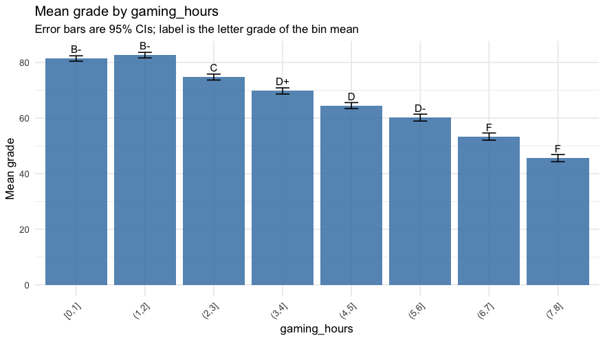

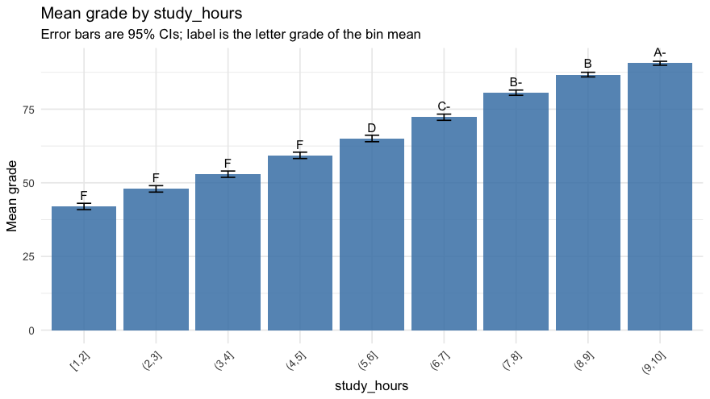

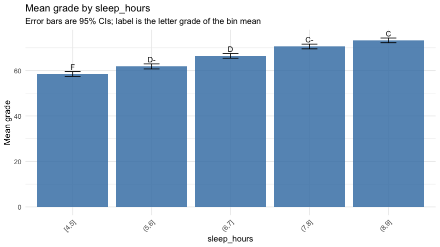

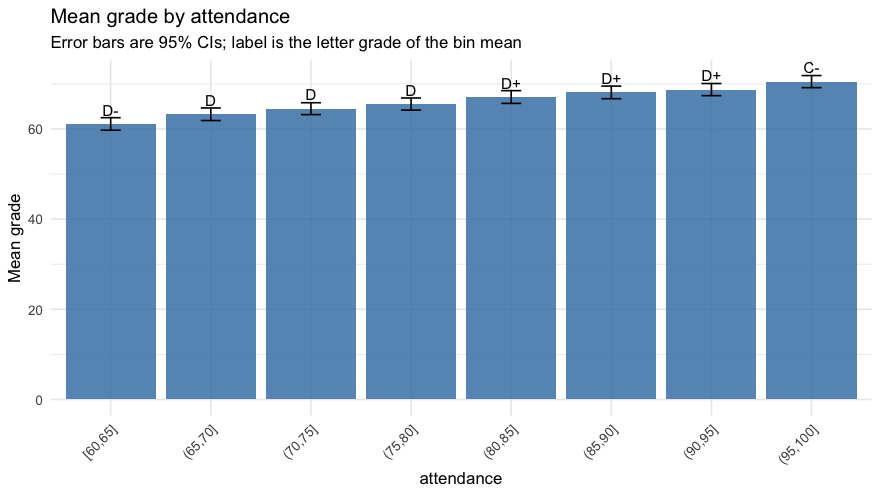

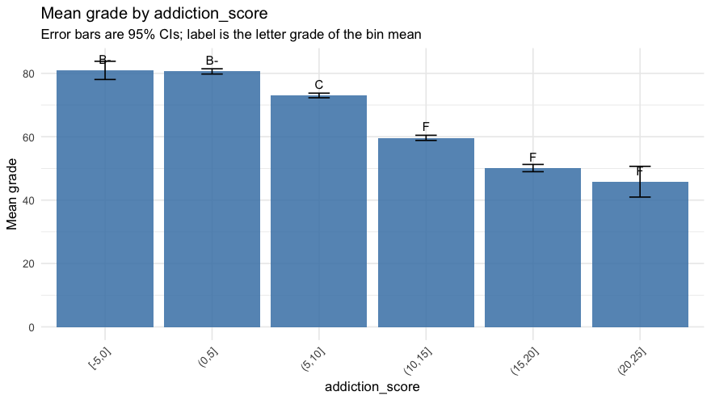

```r
bin_specs <- list(
  gaming_hours    = seq(0, 8, by = 1),
  study_hours     = seq(1, 10, by = 1),
  sleep_hours     = seq(4, 9, by = 1),
  attendance      = seq(60, 100, by = 5),
  addiction_score = seq(-5, 25, by = 5)
)

binned_summary <- function(var, breaks) {
  df %>%
    mutate(bin = cut(.data[[var]], breaks = breaks, include.lowest = TRUE)) %>%
    filter(!is.na(bin)) %>%
    group_by(bin) %>%
    summarise(n = n(), mean_grade = mean(grades),
              se = sd(grades) / sqrt(n()), .groups = "drop") %>%
    mutate(
      ci_low   = mean_grade - 1.96 * se,
      ci_high  = mean_grade + 1.96 * se,
      letter   = to_letter(mean_grade),
      variable = var,
      # Keep the within-variable ordering as a number. Stacking these tables would
      # otherwise merge the factor levels across variables and scramble which bin
      # follows which.
      bin_index = as.integer(bin),
      bin = as.character(bin)
    )
}

all_bins <- imap_dfr(bin_specs, ~ binned_summary(.y, .x))
write_csv(all_bins, "output/binned_means.csv")

for (v in names(bin_specs)) {
  d <- all_bins %>% filter(variable == v) %>%
    mutate(bin = fct_reorder(bin, bin_index))

  p <- ggplot(d, aes(x = bin, y = mean_grade)) +
    geom_col(fill = "steelblue", alpha = 0.85) +
    geom_errorbar(aes(ymin = ci_low, ymax = ci_high), width = 0.2) +
    geom_text(aes(label = letter), vjust = -0.8, size = 3.5) +
    labs(title = paste("Mean grade by", v),
         subtitle = "Error bars are 95% CIs; label is the letter grade of the bin mean",
         x = v, y = "Mean grade") +
    theme_minimal() +
    theme(axis.text.x = element_text(angle = 45, hjust = 1))

  ggsave(paste0("output/binned_", v, ".png"), plot = p,
         width = 8, height = 5, dpi = 150)
  print(p)
}
```

## 5.4 The cutoffs

The steepest drop between neighbouring bins is the plain-language threshold for each factor.

```r
threshold_summary <- all_bins %>%
  group_by(variable) %>%
  arrange(bin_index, .by_group = TRUE) %>%
  mutate(drop = lag(mean_grade) - mean_grade,
         from_bin = lag(bin), from_letter = lag(letter)) %>%
  filter(!is.na(drop)) %>%
  slice_max(drop, n = 1) %>%
  ungroup() %>%
  transmute(
    variable,
    boundary   = paste(from_bin, "->", bin),
    grade_drop = round(drop, 1),
    shift      = paste(from_letter, "->", letter),
    n_after    = n,
    # A non-positive value means grades never actually step down for this factor,
    # so there is no threshold to report.
    threshold  = if_else(drop > 0, "yes", "none found")
  ) %>%
  arrange(desc(grade_drop))

write_csv(threshold_summary, "output/threshold_summary.csv")
tbl(threshold_summary, caption = "Steepest grade drop per factor", digits = 1)
```

Steepest grade drop per factor

| variable | boundary | grade_drop | shift | n_after | threshold |
| --- | --- | --- | --- | --- | --- |
| addiction_score | (5,10] -> (10,15] | 13.4 | C -> F | 2575 | yes |
| gaming_hours | (1,2] -> (2,3] | 7.9 | B- -> C | 970 | yes |
| attendance | (85,90] -> (90,95] | -0.6 | D+ -> D+ | 1004 | none found |
| sleep_hours | (7,8] -> (8,9] | -2.7 | C- -> C | 1580 | none found |
| study_hours | (8,9] -> (9,10] | -3.8 | B -> A- | 861 | none found |

## 5.5 The whole distribution, not just the mean

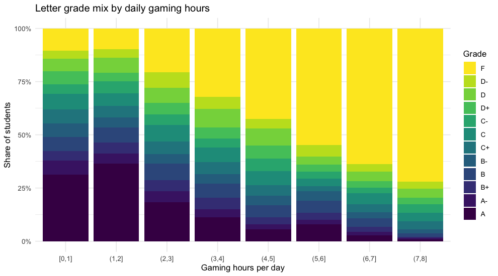

```r
p_mix <- df %>%
  mutate(bin = cut(gaming_hours, breaks = bin_specs$gaming_hours,
                   include.lowest = TRUE)) %>%
  filter(!is.na(bin)) %>%
  count(bin, letter_grade) %>%
  group_by(bin) %>%
  mutate(prop = n / sum(n)) %>%
  ggplot(aes(x = bin, y = prop, fill = letter_grade)) +
  geom_col() +
  scale_fill_viridis_d(direction = -1) +
  scale_y_continuous(labels = scales::percent) +
  labs(title = "Letter grade mix by daily gaming hours",
       x = "Gaming hours per day", y = "Share of students", fill = "Grade") +
  theme_minimal()

ggsave("output/letter_grade_by_gaming.png", p_mix, width = 9, height = 5, dpi = 150)
p_mix
```

A mean can move because everyone slipped a little or because a few students collapsed. This chart settles it: the entire distribution slides down as gaming hours rise, so the threshold is a shift in the whole population, not an artefact of a small tail.

# 6 Predictive modeling

*Source script: `scripts/modeling.R`*

Section 4 established which factors matter. This section asks the two questions a p-value cannot answer: **what shape** is each relationship, and **how well does the model predict students it has never seen**.

## 6.1 Train / test split

```r
set.seed(432)
train_idx <- sample(nrow(df), size = floor(0.7 * nrow(df)))
train <- df[train_idx, ]
test  <- df[-train_idx, ]

cat(sprintf("Training on %d students, testing on %d\n", nrow(train), nrow(test)))
```

```
## Training on 5600 students, testing on 2400
```

```r
# Grades were capped at 100 in cleaning, so a prediction above 100 cannot be right
# no matter what the formula says. Clamp before scoring.
rmse <- function(actual, predicted) sqrt(mean((actual - pmin(predicted, 100))^2))
r2   <- function(actual, predicted) {
  1 - sum((actual - pmin(predicted, 100))^2) / sum((actual - mean(actual))^2)
}
```

## 6.2 Candidate models

Each model adds something the previous one lacked, so the comparison shows whether the extra complexity earns its place.

```r
models <- list(
  # Study hours alone, the strongest single predictor, as a floor to beat.
  study_only = grades ~ study_hours,

  # All five factors, straight line each. This is the model from section 4.3.
  main_effects = grades ~ gaming_hours + study_hours + sleep_hours + attendance +
                          addiction_score,

  # Gaming and addiction both bend rather than run straight (see the EDA scatterplots),
  # so add squared terms.
  with_curves = grades ~ gaming_hours + I(gaming_hours^2) + study_hours + sleep_hours +
                         attendance + addiction_score + I(addiction_score^2),

  # The tree split gaming at a different value in each branch, which is what an
  # interaction term represents: gaming costs more when study hours are low.
  with_interaction = grades ~ gaming_hours * study_hours + I(gaming_hours^2) +
                              sleep_hours + attendance + addiction_score +
                              I(addiction_score^2),

  # addiction_score correlates 0.91 with gaming_hours, so check what dropping it costs.
  no_addiction = grades ~ gaming_hours * study_hours + I(gaming_hours^2) +
                          sleep_hours + attendance
)

fits <- lapply(models, function(f) lm(f, data = train))

comparison_models <- imap_dfr(fits, function(m, name) {
  tibble(
    model      = name,
    n_terms    = length(coef(m)) - 1,
    train_rmse = round(rmse(train$grades, predict(m, train)), 3),
    test_rmse  = round(rmse(test$grades,  predict(m, test)),  3),
    test_r2    = round(r2(test$grades,    predict(m, test)),  4)
  )
})

write_csv(comparison_models, "output/model_comparison.csv")
tbl(comparison_models, caption = "Five candidate models, scored on the held-out test set",
    digits = 4)
```

Five candidate models, scored on the held-out test set

| model | n_terms | train_rmse | test_rmse | test_r2 |
| --- | --- | --- | --- | --- |
| study_only | 1 | 15.153 | 15.107 | 0.5352 |
| main_effects | 5 | 6.332 | 6.187 | 0.9220 |
| with_curves | 7 | 6.194 | 6.045 | 0.9256 |
| with_interaction | 8 | 5.936 | 5.850 | 0.9303 |
| no_addiction | 6 | 5.938 | 5.851 | 0.9303 |

`train_rmse` and `test_rmse` staying close is the sign we are **not overfitting**. If the test error were much worse than the training error, the model would be fitting noise.

## 6.3 Choosing the final model

Not simply the lowest `test_rmse`. Two of these land within 0.001 of each other, which is noise from this particular split rather than a real difference, and picking on raw minimum would hand us extra terms that do nothing. So we take the model with the **fewest terms that gets within 1% of the best error**.

```r
best_rmse <- min(comparison_models$test_rmse)

best_name <- comparison_models %>%
  filter(test_rmse <= best_rmse * 1.01) %>%
  slice_min(n_terms, n = 1) %>%
  slice_min(test_rmse, n = 1) %>%
  pull(model)

cat(sprintf("Best test error: %.3f (%s)\n", best_rmse,
            comparison_models$model[which.min(comparison_models$test_rmse)]))
```

```
## Best test error: 5.850 (with_interaction)
```

```r
cat(sprintf("Chosen for parsimony, within 1%% of best: %s\n", best_name))
```

```
## Chosen for parsimony, within 1% of best: no_addiction
```

```r
# Refit the chosen structure on all 8,000 students for the coefficients we report.
final_model <- lm(models[[best_name]], data = df)

coefs <- tidy(final_model) %>%
  mutate(across(where(is.numeric), ~ round(.x, 4)))

write_csv(coefs, "output/model_coefficients.csv")

coefs %>%
  mutate(p.value = format.pval(p.value, digits = 3, eps = 1e-300)) %>%
  tbl(caption = sprintf(
    "Final model coefficients, fit on all %d students (adjusted R-squared = %.4f, residual SE = %.2f grade points)",
    nrow(df), summary(final_model)$adj.r.squared, summary(final_model)$sigma),
    digits = 4)
```

Final model coefficients, fit on all 8000 students (adjusted R-squared = 0.9265, residual SE = 6.03 grade points)

| term | estimate | std.error | statistic | p.value |
| --- | --- | --- | --- | --- |
| (Intercept) | 11.6389 | 0.6658 | 17.4814 | <1e-300 |
| gaming_hours | -4.5336 | 0.1325 | -34.2285 | <1e-300 |
| study_hours | 4.7146 | 0.0532 | 88.6018 | <1e-300 |
| I(gaming_hours^2) | -0.3489 | 0.0140 | -24.8358 | <1e-300 |
| sleep_hours | 3.7041 | 0.0468 | 79.1847 | <1e-300 |
| attendance | 0.2804 | 0.0058 | 48.1202 | <1e-300 |
| gaming_hours:study_hours | 0.3799 | 0.0114 | 33.3653 | <1e-300 |

## 6.4 Diagnostics

Students sitting exactly on the 100-point cap are flagged separately throughout. Their actual grade was truncated, so their residual is forced negative by the cap rather than by the model being wrong; mixing them into the trend line would misrepresent the fit.

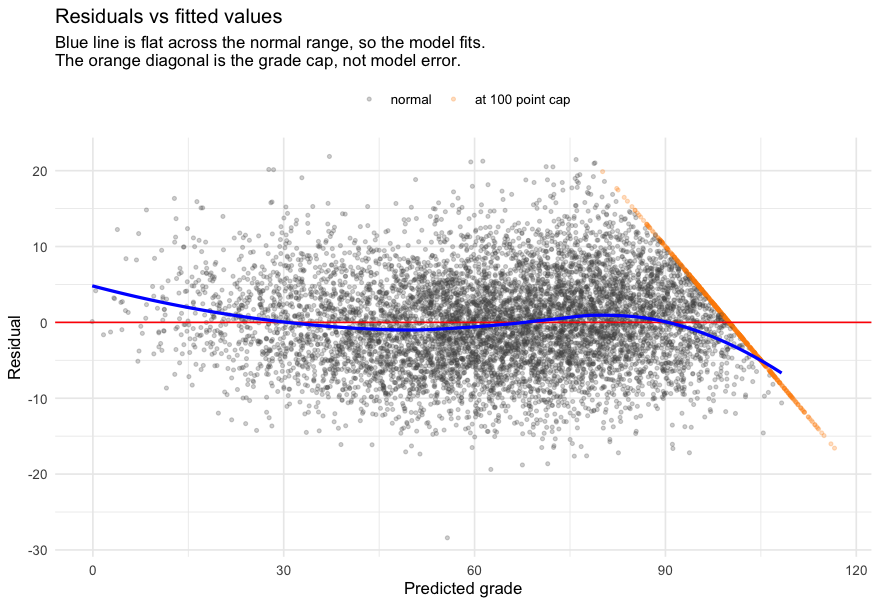

```r
diag_df <- tibble(
  fitted   = fitted(final_model),
  residual = resid(final_model),
  censored = df$grades >= 100
)

p1 <- ggplot(diag_df, aes(x = fitted, y = residual)) +
  geom_point(aes(colour = censored), alpha = 0.25, size = 0.9) +
  geom_hline(yintercept = 0, colour = "red") +
  # Loess on the uncensored students only, so the cap does not drag the line down.
  geom_smooth(data = filter(diag_df, !censored), method = "loess",
              colour = "blue", se = FALSE) +
  scale_colour_manual(values = c("FALSE" = "grey30", "TRUE" = "darkorange"),
                      labels = c("FALSE" = "normal", "TRUE" = "at 100 point cap"),
                      name = NULL) +
  labs(title = "Residuals vs fitted values",
       subtitle = paste("Blue line is flat across the normal range, so the model fits.",
                        "\nThe orange diagonal is the grade cap, not model error."),
       x = "Predicted grade", y = "Residual") +
  theme_minimal() +
  theme(legend.position = "top")

ggsave("output/residuals_vs_fitted.png", p1, width = 8, height = 5.5, dpi = 150)
p1
```

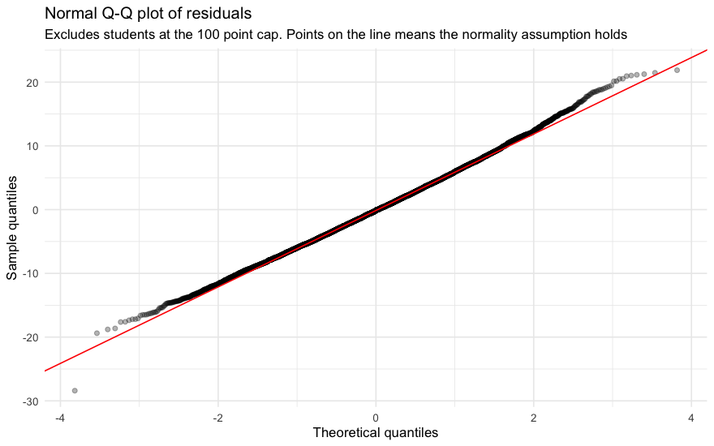

```r
p2 <- ggplot(filter(diag_df, !censored), aes(sample = residual)) +
  stat_qq(alpha = 0.3) +
  stat_qq_line(colour = "red") +
  labs(title = "Normal Q-Q plot of residuals",
       subtitle = "Excludes students at the 100 point cap. Points on the line means the normality assumption holds",
       x = "Theoretical quantiles", y = "Sample quantiles") +
  theme_minimal()

ggsave("output/qq_residuals.png", p2, width = 8, height = 5, dpi = 150)
p2
```

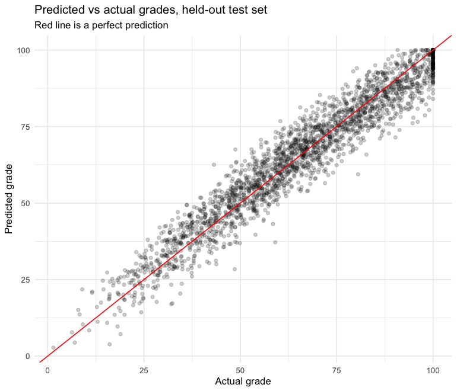

```r
test_pred <- tibble(
  actual    = test$grades,
  predicted = pmin(predict(final_model, test), 100)
)

p3 <- ggplot(test_pred, aes(x = actual, y = predicted)) +
  geom_point(alpha = 0.2) +
  geom_abline(slope = 1, intercept = 0, colour = "red") +
  labs(title = "Predicted vs actual grades, held-out test set",
       subtitle = "Red line is a perfect prediction",
       x = "Actual grade", y = "Predicted grade") +
  theme_minimal()

ggsave("output/predicted_vs_actual.png", p3, width = 7, height = 6, dpi = 150)
p3
```

# 7 Conclusions

## 7.1 What the analysis found

Summary of findings

[output not shown]

## 7.3 Reproducing this report

Everything above runs from the raw CSV. To regenerate the HTML and every file in `output/`:

```r
rmarkdown::render("report/final_report.Rmd")
```

or, from a terminal at the project root:

```
Rscript scripts/render_report.R
```

Session information

| Item | Value |
| --- | --- |
| R version | R version 4.5.3 (2026-03-11) |
| Platform | aarch64-apple-darwin20 |
| Run date | 2026-08-11 11:15 |
| Rows analysed | 8,000 |
| Key packages | tidyverse, broom, rpart, rpart.plot, corrplot |